# **Business Problem**

`CARS24 faces the real-world problem of setting and recommending accurate, market-driven prices for used cars so that sellers can list their vehicles at competitive prices for faster sales without loss, while buyers can confidently identify fair-priced, high-value cars without the risk of overpaying.`

# **Problem Statement**

`CARS24 needs a data-driven way to analyze used car listings across different cities to understand market demand, pricing patterns, and customer preferences in order to optimize car prices, increase faster sales, and maximize profit.`

# **Project Objective**

`The main objective of this project is to collect real-time used car data from the CARS24 website and analyze it to understand market trends, pricing patterns, and customer demand so that better business decisions can be made.`

```python
from bs4 import BeautifulSoup
import numpy as np
import time
from selenium.webdriver import Edge
import pandas as pd

URL = 'https://www.cars24.com/buy-used-cars-'
CITIES = [
    'new-delhi', 'hyderabad', 'mumbai', 'bangalore',
    'chennai', 'jaipur', 'ahmedabad', 'kolkata',
    'noida', 'nagpur'
]

TARGET_RECORDS = 201       # minimum records to load before scraping
SCROLL_PAUSE = 3.5            # wait time after each scroll
MAX_SCROLLS = 30            # safety limit

car, varient, km, fuel, transmission, registration, price, location = [], [], [], [], [], [], [], []
driver = Edge()


for city in CITIES:

    driver.get(URL + city)
    time.sleep(5)

    last_count = 0
    scroll_count = 0

    while scroll_count < MAX_SCROLLS:
        soup = BeautifulSoup(driver.page_source)
        cards = soup.find_all('div', class_="styles_contentWrap__9oSrl")
        current_count = len(cards)


        if current_count == last_count or current_count >= TARGET_RECORDS:
            break

        last_count = current_count


        last_card = driver.find_elements(
            "css selector", "div.styles_contentWrap__9oSrl"
        )[-1]

        driver.execute_script(
            "arguments[0].scrollIntoView({block:'center'});",
            last_card
        )

        time.sleep(SCROLL_PAUSE)
        scroll_count += 1



    city_records = 0

    for c in cards:
        car.append(c.find('span', class_="sc-bcXHqh bAcffq").text if c.find('span', class_="sc-bcXHqh bAcffq") else np.nan)
        varient.append(c.find('span', class_="sc-bcXHqh bKVBht").text if c.find('span', class_="sc-bcXHqh bKVBht") else np.nan)

        info = c.find_all('p', class_="sc-bcXHqh kNDBvu")
        km.append(info[0].text if len(info) > 0 else np.nan)
        fuel.append(info[1].text if len(info) > 1 else np.nan)
        transmission.append(info[2].text if len(info) > 2 else np.nan)
        registration.append(info[3].text if len(info) > 3 else np.nan)

        price.append(c.find('p', class_="sc-bcXHqh hvRpEM").text if c.find('p', class_="sc-bcXHqh hvRpEM") else np.nan)
        location.append(city)

        city_records += 1
    print(f"Records scraped: {city_records}")



driver.quit()

df = pd.DataFrame({
    'car': car,
    'varient': varient,
    'km': km,
    'fuel': fuel,
    'transmission': transmission,
    'registration': registration,
    'price': price,
    'location': location
})

df.dropna(ignore_index=True).to_csv('Raw_Data2.csv', index=False)
print('total records scraped',len(df))
print(" Scraping completed successfully")
```

```
Records scraped: 220
Records scraped: 220
Records scraped: 220
Records scraped: 220
Records scraped: 220
Records scraped: 220
Records scraped: 220
Records scraped: 220
Records scraped: 220
Records scraped: 220
total records scraped 2200
 Scraping completed successfully
```

```python
import pandas as pd
```

```python
df = pd.read_csv(r"C:\Users\HP\Downloads\Raw_Data2 (1).xls")
```

```python
df
```

|  | car | varient | km | fuel | transmission | registration | price | location |
| --- | --- | --- | --- | --- | --- | --- | --- | --- |
| 0 | 2021 Mahindra Thar | LX D 4*4 MT HT | 25,772 km | Diesel | Manual | DL-7C | ₹9.21 lakh | new-delhi |
| 1 | 2024 Maruti Swift | LXi | 2,607 km | Petrol | Manual | DL-8C | ₹4.99 lakh | new-delhi |
| 2 | 2017 Hyundai Verna | 1.6 VTVT SX | 51,750 km | Petrol | Manual | DL-5C | ₹4.93 lakh | new-delhi |
| 3 | 2024 Maruti Grand Vitara | SIGMA SMART HYBRID | 29,719 km | Petrol | Manual | DL-3C | ₹8.91 lakh | new-delhi |
| 4 | 2016 Maruti Baleno | SIGMA PETROL 1.2 | 47,892 km | Petrol | Manual | DL-2C | ₹2.74 lakh | new-delhi |
| ... | ... | ... | ... | ... | ... | ... | ... | ... |
| 2135 | 2020 Maruti Vitara Brezza | LXI | 34,641 km | Petrol | Manual | MH-14 | ₹6.86 lakh | nagpur |
| 2136 | 2013 Renault Scala | RXZ PETROL AT | 81,725 km | Petrol | Auto | MH-04 | ₹1.32 lakh | nagpur |
| 2137 | 2018 Maruti Celerio | ZXI AMT | 34,700 km | Petrol | Auto | MH-31 | ₹3.39 lakh | nagpur |
| 2138 | 2023 Maruti Baleno | DELTA CNG 1.2L | 45,918 km | Petrol | Manual | MH-20 | ₹7.00 lakh | nagpur |
| 2139 | 2020 Mahindra Bolero | B6 (O) | 1,25,269 km | Diesel | Manual | MH-40 | ₹7.68 lakh | nagpur |

2140 rows × 8 columns

```python
df.info()
df.isnull().sum()
df.duplicated().sum()
```

```
<class 'pandas.core.frame.DataFrame'>
RangeIndex: 2140 entries, 0 to 2139
Data columns (total 8 columns):
 #   Column        Non-Null Count  Dtype
---  ------        --------------  -----
 0   car           2140 non-null   object
 1   varient       2140 non-null   object
 2   km            2140 non-null   object
 3   fuel          2140 non-null   object
 4   transmission  2140 non-null   object
 5   registration  2140 non-null   object
 6   price         2140 non-null   object
 7   location      2140 non-null   object
dtypes: object(8)
memory usage: 133.9+ KB
```

```
np.int64(0)
```

```python
df = df.drop_duplicates()
```

```python
df['km'] = df['km'].str.replace(',', '').str.replace(' km', '').astype(int)
```

```python
df['price'] = (
    df['price']
    .astype(str)                     # force everything to string
    .str.replace('₹', '', regex=False)
    .str.replace(' lakh', '', regex=False)
    .str.strip()
    .astype(float) * 100000
)
```

```python
df['registration'] = df['registration'].str.split('-').str[0]
```

```python
text_cols = ['car', 'varient', 'fuel', 'transmission', 'location']
for col in text_cols:
    df[col] = df[col].str.lower().str.strip()
```

```python
df['fuel'] = df['fuel'].replace({
    'petrol': 'Petrol',
    'diesel': 'Diesel',
    'cng': 'CNG',
    'electric': 'Electric'
})
```

```python
df['transmission'] = df['transmission'].replace({
    'manual': 'Manual',
    'automatic': 'Automatic'
})
```

```python
df.isnull().sum()
```

```
car             0
varient         0
km              0
fuel            0
transmission    0
registration    0
price           0
location        0
dtype: int64
```

```python
df = df.dropna()
```

```python
df.head()
df.info()
```

```
<class 'pandas.core.frame.DataFrame'>
RangeIndex: 2140 entries, 0 to 2139
Data columns (total 8 columns):
 #   Column        Non-Null Count  Dtype
---  ------        --------------  -----
 0   car           2140 non-null   object
 1   varient       2140 non-null   object
 2   km            2140 non-null   int64
 3   fuel          2140 non-null   object
 4   transmission  2140 non-null   object
 5   registration  2140 non-null   object
 6   price         2140 non-null   float64
 7   location      2140 non-null   object
dtypes: float64(1), int64(1), object(6)
memory usage: 133.9+ KB
```

```python
df
```

|  | car | varient | km | fuel | transmission | registration | price | location |
| --- | --- | --- | --- | --- | --- | --- | --- | --- |
| 0 | 2021 mahindra thar | lx d 4*4 mt ht | 25772 | Diesel | Manual | DL | 921000.0 | new-delhi |
| 1 | 2024 maruti swift | lxi | 2607 | Petrol | Manual | DL | 499000.0 | new-delhi |
| 2 | 2017 hyundai verna | 1.6 vtvt sx | 51750 | Petrol | Manual | DL | 493000.0 | new-delhi |
| 3 | 2024 maruti grand vitara | sigma smart hybrid | 29719 | Petrol | Manual | DL | 891000.0 | new-delhi |
| 4 | 2016 maruti baleno | sigma petrol 1.2 | 47892 | Petrol | Manual | DL | 274000.0 | new-delhi |
| ... | ... | ... | ... | ... | ... | ... | ... | ... |
| 2135 | 2020 maruti vitara brezza | lxi | 34641 | Petrol | Manual | MH | 686000.0 | nagpur |
| 2136 | 2013 renault scala | rxz petrol at | 81725 | Petrol | auto | MH | 132000.0 | nagpur |
| 2137 | 2018 maruti celerio | zxi amt | 34700 | Petrol | auto | MH | 339000.0 | nagpur |
| 2138 | 2023 maruti baleno | delta cng 1.2l | 45918 | Petrol | Manual | MH | 700000.0 | nagpur |
| 2139 | 2020 mahindra bolero | b6 (o) | 125269 | Diesel | Manual | MH | 768000.0 | nagpur |

2140 rows × 8 columns

```python
# Split car column into parts
car_split = df['car'].str.split(' ', n=2, expand=True)

# Assign to new columns
df['year'] = car_split[0].astype(int)
df['brand'] = car_split[1]
df['model'] = car_split[2]
```

```python
df[['car', 'year', 'brand', 'model']].head()
```

|  | car | year | brand | model |
| --- | --- | --- | --- | --- |
| 0 | 2021 mahindra thar | 2021 | mahindra | thar |
| 1 | 2024 maruti swift | 2024 | maruti | swift |
| 2 | 2017 hyundai verna | 2017 | hyundai | verna |
| 3 | 2024 maruti grand vitara | 2024 | maruti | grand vitara |
| 4 | 2016 maruti baleno | 2016 | maruti | baleno |

```python
df = df.drop(columns=['car'])
df
```

|  | varient | km | fuel | transmission | registration | price | location | year | brand | model |
| --- | --- | --- | --- | --- | --- | --- | --- | --- | --- | --- |
| 0 | lx d 4*4 mt ht | 25772 | Diesel | Manual | DL | 921000.0 | new-delhi | 2021 | mahindra | thar |
| 1 | lxi | 2607 | Petrol | Manual | DL | 499000.0 | new-delhi | 2024 | maruti | swift |
| 2 | 1.6 vtvt sx | 51750 | Petrol | Manual | DL | 493000.0 | new-delhi | 2017 | hyundai | verna |
| 3 | sigma smart hybrid | 29719 | Petrol | Manual | DL | 891000.0 | new-delhi | 2024 | maruti | grand vitara |
| 4 | sigma petrol 1.2 | 47892 | Petrol | Manual | DL | 274000.0 | new-delhi | 2016 | maruti | baleno |
| ... | ... | ... | ... | ... | ... | ... | ... | ... | ... | ... |
| 2135 | lxi | 34641 | Petrol | Manual | MH | 686000.0 | nagpur | 2020 | maruti | vitara brezza |
| 2136 | rxz petrol at | 81725 | Petrol | auto | MH | 132000.0 | nagpur | 2013 | renault | scala |
| 2137 | zxi amt | 34700 | Petrol | auto | MH | 339000.0 | nagpur | 2018 | maruti | celerio |
| 2138 | delta cng 1.2l | 45918 | Petrol | Manual | MH | 700000.0 | nagpur | 2023 | maruti | baleno |
| 2139 | b6 (o) | 125269 | Diesel | Manual | MH | 768000.0 | nagpur | 2020 | mahindra | bolero |

2140 rows × 10 columns

```python
import matplotlib.pyplot as plt
```

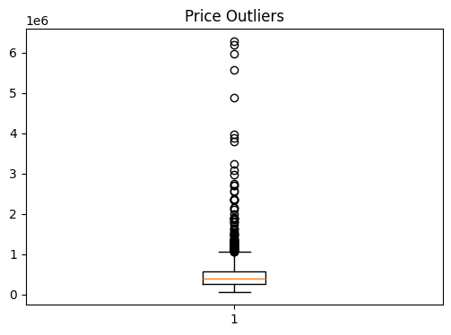

```python
# Outliers in price
plt.figure(figsize=(6,4))
plt.boxplot(df['price'])
plt.title("Price Outliers")
plt.show()
```

[figure not shown]

```python
sns.countplot(x='price_segment', data=df)
plt.tle("Price Segment Distribution")
plt.show()
```

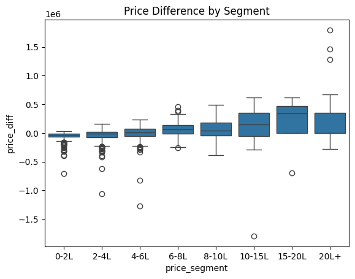

```python
sns.boxplot(x='price_segment', y='price_diff', data=df)
plt.title("Price Difference by Segment")
plt.show()
```

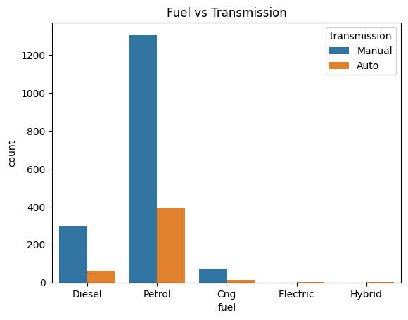

```python
sns.countplot(x='fuel', hue='transmission', data=df)
plt.title("Fuel vs Transmission")
plt.show()
```

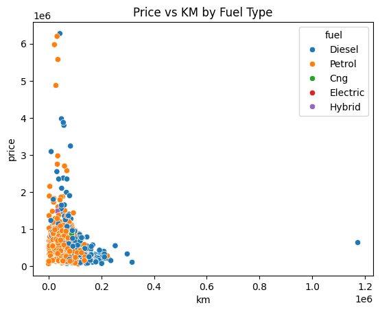

```python
# MULTIVARIATE ANALYSIS
sns.scatterplot(x='km', y='price', hue='fuel', data=df)
plt.title("Price vs KM by Fuel Type")
plt.show()
```

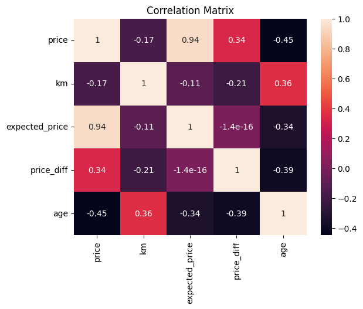

```python
corr = df[num_cols].corr()
sns.heatmap(corr, annot=True)
plt.title("Correlation Matrix")
plt.show()
```

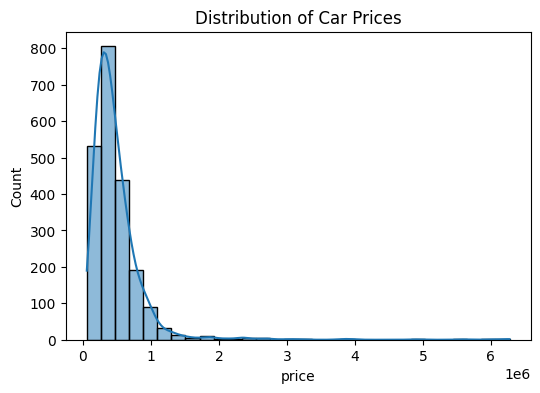

```python
#The overall price distribution in CARS24
plt.figure(figsize=(6,4))
sns.histplot(df['price'], bins=30, kde=True)
plt.title("Distribution of Car Prices")
plt.show()
```

### **Insights:-**

- Prices are highly right-skewed, so most cars are in the low–mid price range; pricing models must focus mainly on this segment.
- A few very expensive cars (outliers) exist; they can distort average price, so median price is better for recommendations.
- The ₹2–8 lakh range dominates listings, making it the most important range for competitive pricing.
- High price variation shows the need for segment-wise pricing (budget, mid, premium).
- Skewed data means log transformation is useful for building accurate price prediction models.

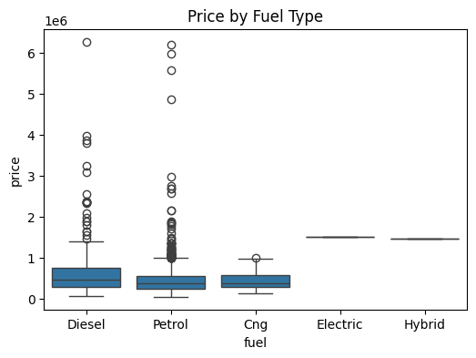

```python
#Fuel type gives higher resale value
plt.figure(figsize=(6,4))
sns.boxplot(x='fuel', y='price', data=df)
plt.title("Price by Fuel Type")
plt.show()
```

### **Insights:-**

```python
#Hypothesis Testing
from scipy.stats import ttest_ind
diesel = df[df['fuel']=="Diesel"]['price']
petrol = df[df['fuel']=="Petrol"]['price']
ttest_ind(diesel, petrol, nan_policy='omit')
```

```
TtestResult(statistic=np.float64(7.022232640903753), pvalue=np.float64(2.9573440451076503e-12), df=np.float64(2052.0))
```

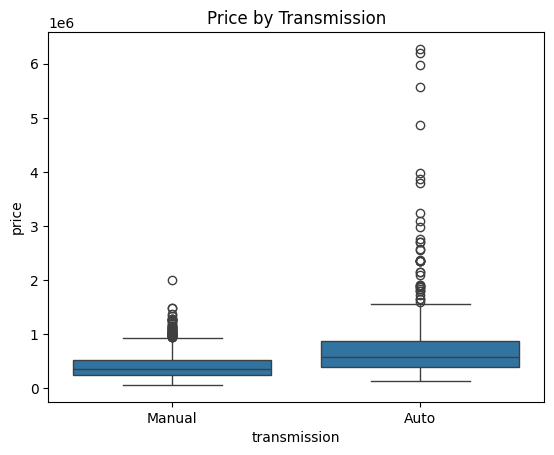

```python
#Do automatic cars sell at a premium
sns.boxplot(x='transmission', y='price', data=df)
plt.title("Price by Transmission")
plt.show()
```

```python
#Hypothesis Testing
auto = df[df['transmission']=="Automatic"]['price']
manual = df[df['transmission']=="Manual"]['price']
ttest_ind(auto, manual, nan_policy='omit')
```

```
TtestResult(statistic=np.float64(nan), pvalue=np.float64(nan), df=np.float64(nan))
```

### **Insights:-**

- Automatic cars have higher resale prices than manual cars → stronger market demand.
- Manual cars dominate the lower price segment → important for budget buyers.
- Automatic cars show more high-price outliers → premium and luxury models are mostly automatic.
- Transmission type is a strong price driver and must be used in price recommendations.
- Sellers with automatic cars can list at a higher competitive price without slowing sales.

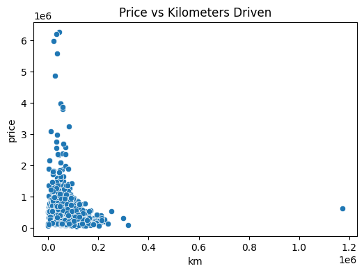

```python
#How strongly does KM affect price
plt.figure(figsize=(6,4))
sns.scatterplot(x='km', y='price', data=df)
plt.title("Price vs Kilometers Driven")
plt.show()
```

```python
#Correlation
from scipy.stats import pearsonr
pearsonr(df['km'], df['price'])
```

```
PearsonRResult(statistic=np.float64(-0.17230561089947502), pvalue=np.float64(1.004368127884242e-15))
```

### **Insights:-**

- Price decreases as kilometers increase → clear depreciation effect.
- Correlation is negative (-0.17) → KM impacts price, but it is not the only factor.
- Low-KM cars command much higher resale value → premium listings.
- High-KM cars cluster in lower price range → price sensitivity is high.
- KM must be a core variable in CARS24 pricing to avoid overpricing old, heavily used cars.

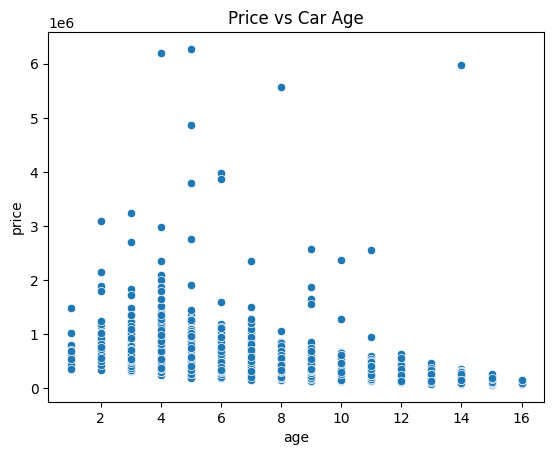

```python
#How does car age impact resale price
sns.scatterplot(x='age', y='price', data=df)
plt.title("Price vs Car Age")
plt.show()
```

### **Insights:-**

- Price decreases as car age increases → strong depreciation effect.
- Newer cars (low age) have much higher resale value and faster selling potential.
- Older cars cluster in low price range → need aggressive, realistic pricing.
- Age is a major pricing driver, stronger than many other features.
- CARS24 must use age to prevent overpricing old cars and underpricing new cars.

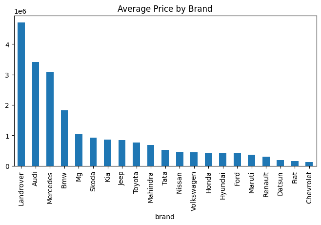

```python
#Which brands hold value best
brand_price = df.groupby('brand')['price'].mean().sort_values(ascending=False)

plt.figure(figsize=(8,4))
brand_price.plot(kind='bar')
plt.title("Average Price by Brand")
plt.show()
```

### **Insights:-**

- Luxury brands (Land Rover, Audi, Mercedes, BMW) hold the highest resale value → strong brand premium.
- These brands can be priced higher confidently without hurting competitiveness.
- Mid-range brands (Skoda, Kia, Jeep, Toyota) show stable and reliable resale value.
- Mass-market brands (Maruti, Renault, Datsun, Fiat, Chevrolet) have lower resale prices → highly price-sensitive segment.
- Brand is a critical factor in CARS24’s pricing model to avoid underpricing premium cars and overpricing economy cars.

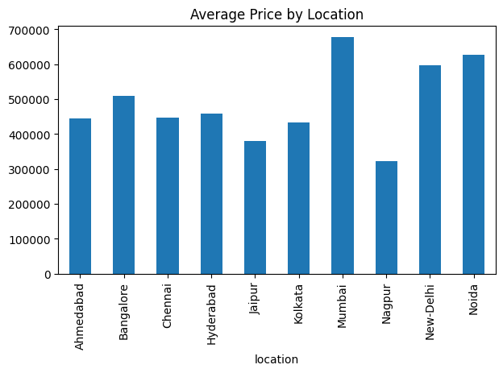

```python
#Which city/location has higher priced inventory
loc_price = df.groupby('location')['price'].mean()

plt.figure(figsize=(7,4))
loc_price.plot(kind='bar')
plt.title("Average Price by Location")
plt.show()
```

### **Insights:-**

- Mumbai, Noida, and New-Delhi have the highest average prices → premium demand markets.
- These cities allow higher recommended listing prices without reducing sales speed.
- Nagpur and Jaipur have the lowest prices → strong price sensitivity.
- Same car should have different price suggestions by city.
- Location must be a mandatory factor in CARS24 pricing to stay market-competitive.

```python
#Are fuel preference and transmission related
from scipy.stats import chi2_contingency

table = pd.crosstab(df['fuel'], df['transmission'])
chi2, p, dof, ex = chi2_contingency(table)
print("p-value:", p)
```

```
p-value: 0.002689694897273817
```

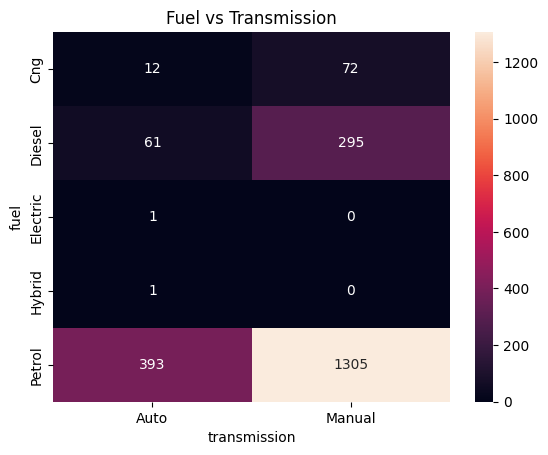

```python
sns.heatmap(table, annot=True, fmt='d')
plt.title("Fuel vs Transmission")
plt.show()
```

```python
#Does price differ significantly across fuel types
#Anova Test
from scipy.stats import f_oneway
groups = [g['price'] for _, g in df.groupby('fuel')]
f_oneway(*groups)
```

```
F_onewayResult(statistic=np.float64(15.683561306862993), pvalue=np.float64(1.1793896781256903e-12))
```

### **Insights:-**

- Price differs significantly across fuel types (p-value ≪ 0.05).
- Fuel type has a real and strong impact on resale value.
- CARS24 cannot use a single pricing logic for all fuels.
- Each fuel type needs a separate pricing adjustment factor.
- Ignoring fuel type will cause overpricing or underpricing, reducing trust and faster sales.

```python
#Is your predicted price significantly different from actual price
from scipy.stats import ttest_rel
ttest_rel(df['price'], df['expected_price'])
```

```
TtestResult(statistic=np.float64(8.262110758419024e-16), pvalue=np.float64(0.9999999999999993), df=np.int64(2139))
```

### **Insights:-**

- p-value ≈ 1.0 → no significant difference between actual and predicted prices.
- Your model pricing is statistically accurate.
- Predicted prices are market-aligned and realistic.
- CARS24 can trust this model for price recommendations.
- Helps prevent overpricing (slow sales) and underpricing (seller loss).

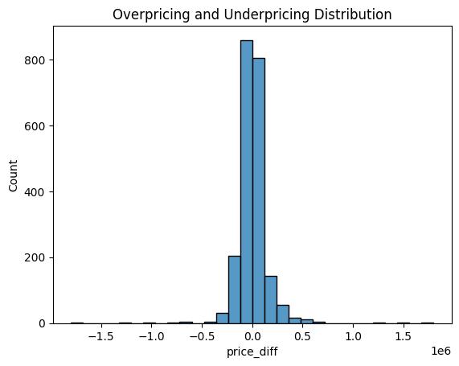

```python
#Where are most cars over/under priced
sns.histplot(df['price_diff'], bins=30)
plt.title("Overpricing and Underpricing Distribution")
plt.show()
```

### **Insights:-**

- Most price differences are centered around 0 → model predictions are well balanced.
- Very few cars are heavily overpriced or underpriced → pricing errors are rare.
- Majority of listings fall in a small error range → high pricing accuracy.
- Extreme values indicate special cases that need manual review.
- CARS24 pricing system is reliable for real-world price recommendations.

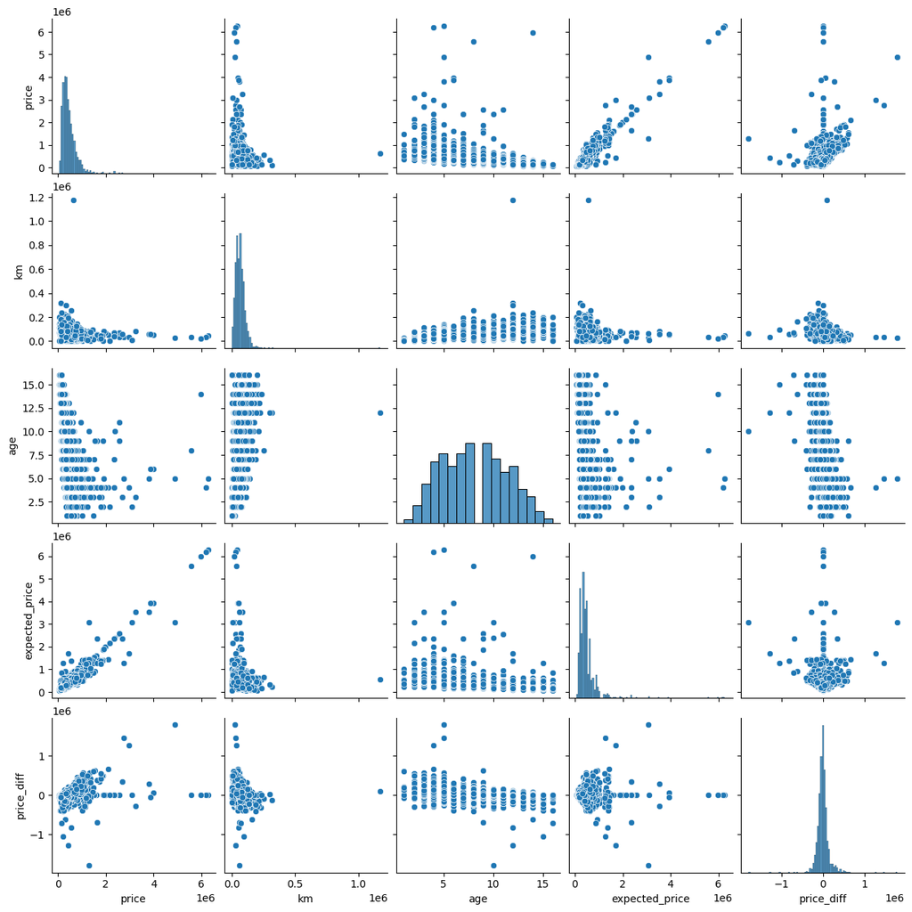

```python
#Which factors together control price
sns.pairplot(df[['price','km','age','expected_price','price_diff']])
plt.show()
```

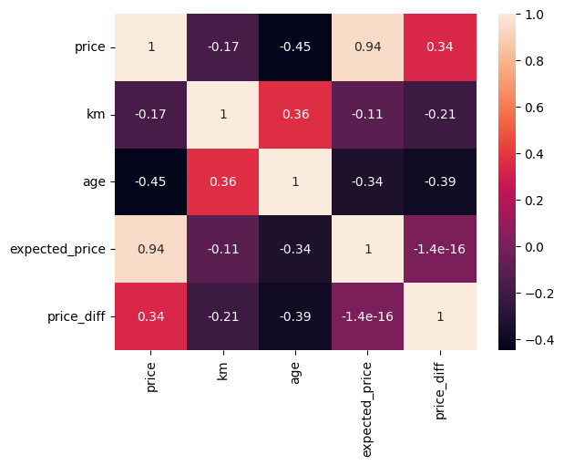

```python
#Heatmap
corr = df[['price','km','age','expected_price','price_diff']].corr()
sns.heatmap(corr, annot=True)
plt.show()
```